# Analysis of Movie Ratings Trends Over Time

Prasham

03/17/2025

# Loading Libraries and Data:

```r
library(readr)

previous <- read_csv('fandango_score_comparison.csv')
after <- read_csv('movie_ratings_16_17.csv')

head(previous)
```

```
## # A tibble: 6 × 22
##   FILM       RottenTomatoes RottenTomatoes_User Metacritic Metacritic_User  IMDB
##   <chr>               <dbl>               <dbl>      <dbl>           <dbl> <dbl>
## 1 Avengers:…             74                  86         66             7.1   7.8
## 2 Cinderell…             85                  80         67             7.5   7.1
## 3 Ant-Man (…             80                  90         64             8.1   7.8
## 4 Do You Be…             18                  84         22             4.7   5.4
## 5 Hot Tub T…             14                  28         29             3.4   5.1
## 6 The Water…             63                  62         50             6.8   7.2
## # ℹ 16 more variables: Fandango_Stars <dbl>, Fandango_Ratingvalue <dbl>,
## #   RT_norm <dbl>, RT_user_norm <dbl>, Metacritic_norm <dbl>,
## #   Metacritic_user_nom <dbl>, IMDB_norm <dbl>, RT_norm_round <dbl>,
## #   RT_user_norm_round <dbl>, Metacritic_norm_round <dbl>,
## #   Metacritic_user_norm_round <dbl>, IMDB_norm_round <dbl>,
## #   Metacritic_user_vote_count <dbl>, IMDB_user_vote_count <dbl>,
## #   Fandango_votes <dbl>, Fandango_Difference <dbl>
```

# Previewing the after Dataset:

```r
head(after)
```

```
## # A tibble: 6 × 15
##   movie         year metascore  imdb tmeter audience fandango n_metascore n_imdb
##   <chr>        <dbl>     <dbl> <dbl>  <dbl>    <dbl>    <dbl>       <dbl>  <dbl>
## 1 10 Cloverfi…  2016        76   7.2     90       79      3.5        3.8    3.6
## 2 13 Hours      2016        48   7.3     50       83      4.5        2.4    3.65
## 3 A Cure for …  2016        47   6.6     40       47      3          2.35   3.3
## 4 A Dog's Pur…  2017        43   5.2     33       76      4.5        2.15   2.6
## 5 A Hologram …  2016        58   6.1     70       57      3          2.9    3.05
## 6 A Monster C…  2016        76   7.5     87       84      4          3.8    3.75
## # ℹ 6 more variables: n_tmeter <dbl>, n_audience <dbl>, nr_metascore <dbl>,
## #   nr_imdb <dbl>, nr_tmeter <dbl>, nr_audience <dbl>
```

# Data Selection and Preview for Fandango Movie Ratings Analysis:

I selected specific columns from the previous and after datasets to focus on important information such as movie names, ratings, and votes. This helped simplify the analysis by narrowing down the data. Then, I previewed the first few rows to ensure the selection was correct and the data was ready for further analysis.

```r
library(dplyr)
fandango_previous <- previous %>%
  select(FILM, Fandango_Stars, Fandango_Ratingvalue,
         Fandango_votes, Fandango_Difference)

fandango_after <- after %>%
  select(movie, year, fandango)

head(fandango_previous)
```

```
## # A tibble: 6 × 5
##   FILM    Fandango_Stars Fandango_Ratingvalue Fandango_votes Fandango_Difference
##   <chr>            <dbl>                <dbl>          <dbl>               <dbl>
## 1 Avenge…            5                    4.5          14846                 0.5
## 2 Cinder…            5                    4.5          12640                 0.5
## 3 Ant-Ma…            5                    4.5          12055                 0.5
## 4 Do You…            5                    4.5           1793                 0.5
## 5 Hot Tu…            3.5                  3             1021                 0.5
## 6 The Wa…            4.5                  4              397                 0.5
```

# Previewing the fandango_after Dataset:

```r
head(fandango_after)
```

```
## # A tibble: 6 × 3
##   movie                    year fandango
##   <chr>                   <dbl>    <dbl>
## 1 10 Cloverfield Lane      2016      3.5
## 2 13 Hours                 2016      4.5
## 3 A Cure for Wellness      2016      3
## 4 A Dog's Purpose          2017      4.5
## 5 A Hologram for the King  2016      3
## 6 A Monster Calls          2016      4
```

# Random Sampling of Movies from the Fandango Dataset:

I used the set.seed() function to ensure reproducibility and then randomly selected 10 movies from the fandango_after dataset using sample_n(). This step helps to create a smaller, manageable subset of data for quick checks or for further detailed analysis without working with the entire dataset.

```r
set.seed(1)
sample_n(fandango_after, size = 10)
```

```
## # A tibble: 10 × 3
##    movie                     year fandango
##    <chr>                    <dbl>    <dbl>
##  1 Hands of Stone            2016      4
##  2 The Bye Bye Man           2017      3
##  3 Our Kind of Traitor       2016      3.5
##  4 The Autopsy of Jane Doe   2016      4.5
##  5 Dirty Grandpa             2016      3.5
##  6 Arsenal                   2017      3.5
##  7 The Light Between Oceans  2016      4
##  8 Exposed                   2016      2.5
##  9 Jason Bourne              2016      4
## 10 Before I Fall             2017      3.5
```

# Adding Rotten Tomato Review Counts to Random Sampled Movies:

I first randomly selected 10 movies from the fandango_after dataset using sample_n(), ensuring reproducibility with set.seed(). Then, I created a new dataset containing the Rotten Tomato review counts for each of the selected movies. Finally, I combined the two datasets using bind_cols() to add the review counts to the randomly sampled movie data, making it ready for analysis.

```r
set.seed(1)
sampled <- sample_n(fandango_after, size = 10)
reviews <- tibble(reviews = c(13569, 74904, 24293, 4141, 30183, 48952, 14328, 59359, 54765, 82222))
bind_cols(sampled, reviews)
```

```
## # A tibble: 10 × 4
##    movie                     year fandango reviews
##    <chr>                    <dbl>    <dbl>   <dbl>
##  1 Hands of Stone            2016      4     13569
##  2 The Bye Bye Man           2017      3     74904
##  3 Our Kind of Traitor       2016      3.5   24293
##  4 The Autopsy of Jane Doe   2016      4.5    4141
##  5 Dirty Grandpa             2016      3.5   30183
##  6 Arsenal                   2017      3.5   48952
##  7 The Light Between Oceans  2016      4     14328
##  8 Exposed                   2016      2.5   59359
##  9 Jason Bourne              2016      4     54765
## 10 Before I Fall             2017      3.5   82222
```

# Counting Movies with Fewer Than 30 Votes:

```r
sum(fandango_previous$Fandango_votes < 30)
```

```
## [1] 0
```

# Previewing the First 10 Movie Titles:

```r
head(fandango_previous$FILM, n = 10)
```

```
##  [1] "Avengers: Age of Ultron (2015)" "Cinderella (2015)"
##  [3] "Ant-Man (2015)"                 "Do You Believe? (2015)"
##  [5] "Hot Tub Time Machine 2 (2015)"  "The Water Diviner (2015)"
##  [7] "Irrational Man (2015)"          "Top Five (2014)"
##  [9] "Shaun the Sheep Movie (2015)"   "Love & Mercy (2015)"
```

# Identifying Unique Years in the Fandango After Dataset:

```r
unique(fandango_after$year)
```

```
## [1] 2016 2017
```

# Extracting Year from Movie Titles:

```r
library(stringr)
fandango_previous <- fandango_previous %>%
  mutate(year = str_sub(FILM, -5, -2))
```

# Grouping Movies by Year and Counting Frequency:

```r
fandango_previous %>%
  group_by(year) %>%
  summarize(Freq = n())
```

```
## # A tibble: 2 × 2
##   year   Freq
##   <chr> <int>
## 1 2014     17
## 2 2015    129
```

# Creating a Frequency Table for Movie Years

```r
table(fandango_previous$year)
```

```
##
## 2014 2015
##   17  129
```

# Filtering Data for 2015 Movies:

```r
fandango_2015 <- fandango_previous %>%
  filter(year == 2015)
table(fandango_2015$year)
```

```
##
## 2015
##  129
```

# Previewing the First 6 Movies in the Fandango After Dataset:

```r
head(fandango_after)
```

```
## # A tibble: 6 × 3
##   movie                    year fandango
##   <chr>                   <dbl>    <dbl>
## 1 10 Cloverfield Lane      2016      3.5
## 2 13 Hours                 2016      4.5
## 3 A Cure for Wellness      2016      3
## 4 A Dog's Purpose          2017      4.5
## 5 A Hologram for the King  2016      3
## 6 A Monster Calls          2016      4
```

# Creating a Frequency Table for Movie Years in the Fandango After Dataset:

```r
table(fandango_after$year)
```

```
##
## 2016 2017
##  191   23
```

# Filtering Data for 2016 Movies:

```r
fandango_2016 <- fandango_after %>%
  filter(year == 2016)
table(fandango_2016$year)
```

```
##
## 2016
##  191
```

# Creating a Density Plot to Compare Fandango Ratings in 2015 vs 2016:

I created a density plot to compare the distribution shapes of Fandango ratings for 2015 and 2016. The plot overlays the density of ratings for both years, allowing for a clear visual comparison of the distribution. The 2015 ratings are represented by the default color, while the 2016 ratings are shown in blue.

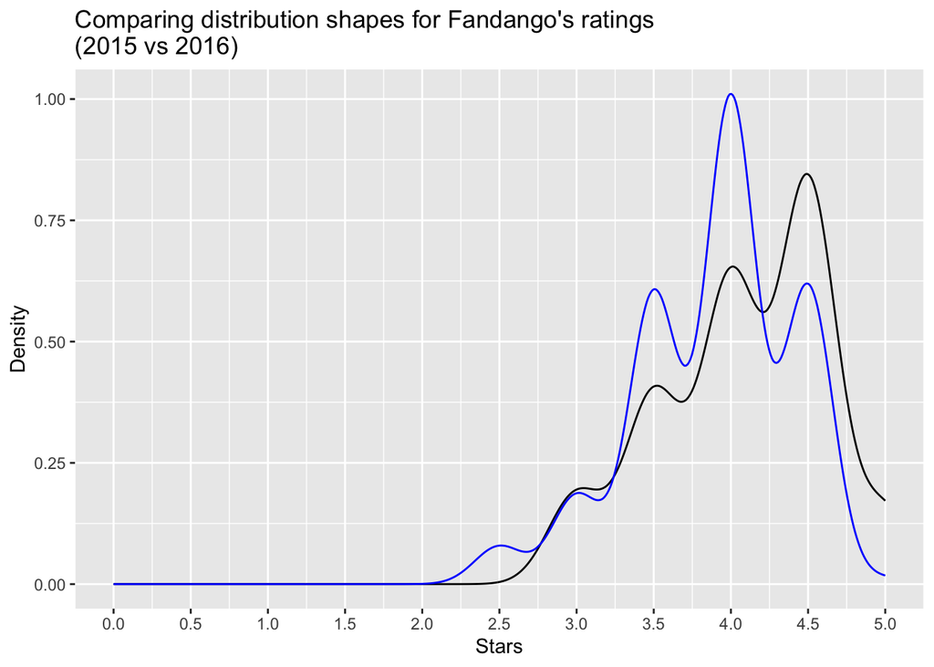

```r
library(ggplot2)
ggplot(data = fandango_2015,
               aes(x = Fandango_Stars)) +
  geom_density() +
  geom_density(data = fandango_2016,
               aes(x = fandango), color = "blue") +
  labs(title = "Comparing distribution shapes for Fandango's ratings\n(2015 vs 2016)",
       x = "Stars",
       y = "Density") +
  scale_x_continuous(breaks = seq(0, 5, by = 0.5),
                     limits = c(0, 5))
```

# Calculating the Percentage of Each Fandango Rating for 2015 Movies:

I calculated the percentage of each Fandango rating (from 3.0 to 5.0) for the movies released in 2015. This helps to understand the distribution of ratings and how frequently each rating occurred among the popular movies in that year.

```r
fandango_2015 %>%
  group_by(Fandango_Stars) %>%
  summarize(Percentage = n() / nrow(fandango_2015) * 100)
```

```
## # A tibble: 5 × 2
##   Fandango_Stars Percentage
##            <dbl>      <dbl>
## 1            3         8.53
## 2            3.5      17.8
## 3            4        28.7
## 4            4.5      38.0
## 5            5         6.98
```

# Calculating the Percentage of Each Fandango Rating for 2016 Movies:

```r
fandango_2016 %>%
  group_by(fandango) %>%
  summarize(Percentage = n() / nrow(fandango_2016) * 100)
```

```
## # A tibble: 6 × 2
##   fandango Percentage
##      <dbl>      <dbl>
## 1      2.5      3.14
## 2      3        7.33
## 3      3.5     24.1
## 4      4       40.3
## 5      4.5     24.6
## 6      5        0.524
```

# Calculating Summary Statistics for 2015 and 2016 Fandango Ratings:

I first defined a custom mode function to calculate the most frequent rating value for the datasets. Then, I calculated the mean, median, and mode for Fandango ratings in 2015 and 2016. I combined the summary statistics for both years into one dataset and reshaped it into a format suitable for visualization with ggplot.

```r
library(tidyr)

mode <- function(x) {
  ux <- unique(x)
  ux[which.max(tabulate(match(x, ux)))]
}

summary_2015 <- fandango_2015 %>%
  summarize(year = "2015",
    mean = mean(Fandango_Stars),
    median = median(Fandango_Stars),
    mode = mode(Fandango_Stars))

summary_2016 <- fandango_2016 %>%
  summarize(year = "2016",
            mean = mean(fandango),
            median = median(fandango),
            mode = mode(fandango))

summary_df <- bind_rows(summary_2015, summary_2016)

summary_df <- summary_df %>%
  gather(key = "statistic", value = "value", - year)

summary_df
```

```
## # A tibble: 6 × 3
##   year  statistic value
##   <chr> <chr>     <dbl>
## 1 2015  mean       4.09
## 2 2016  mean       3.89
## 3 2015  median     4
## 4 2016  median     4
## 5 2015  mode       4.5
## 6 2016  mode       4
```

# Visualizing Summary Statistics for 2015 and 2016 Fandango Ratings:

I created a bar plot to compare the mean, median, and mode of Fandango ratings for 2015 and 2016. The bars represent each statistic (mean, median, and mode), with different colors indicating the two years. The chart provides a visual comparison of the distribution of ratings across the two years.

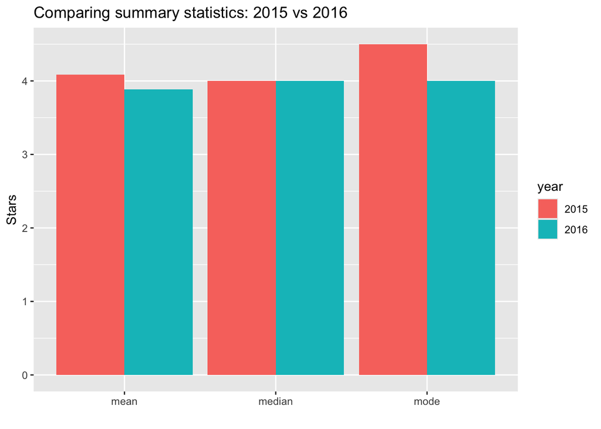

```r
ggplot(data = summary_df, aes(x = statistic, y = value, fill = year)) +
  geom_bar(stat = "identity", position = "dodge") +
  labs(title = "Comparing summary statistics: 2015 vs 2016",
       x = "",
       y = "Stars")
```

# Calculating the Change in Mean Fandango Ratings from 2015 to 2016:

```r
means <- summary_df %>%
  filter(statistic == "mean")

means %>%
  summarize(change = (value[1] - value[2]) / value[1])
```

```
## # A tibble: 1 × 1
##   change
##    <dbl>
## 1 0.0484
```

# Conclusion

The analysis revealed a small but noticeable difference between the Fandango ratings for popular movies in 2015 and those in 2016. On average, popular movies released in 2016 received lower ratings on Fandango compared to their 2015 counterparts. This shift can be attributed to Fandango addressing the bias in its rating system following Hickey’s analysis.